# Lecture 06

Author

Bill Perry

# Lecture 5: Review

Covered

- Statistical inference fundamentals
- Hypothesis testing principles
- T Distributions
- One sample T Tests
- Two sample T Tests
- Paired T Tests

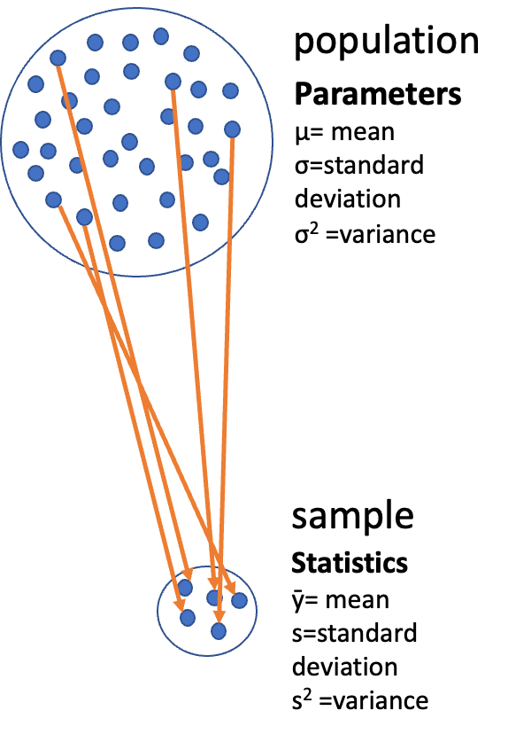

# **Lecture 6:** Overview

## The objectives:

- Brief review
- Hypothesis tests for two populations
- Assumptions of parametric tests
- Power of Parametric Tests
- Introduction to Non-Parametric Tests

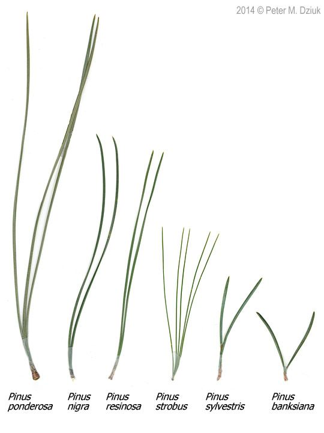

# **Lecture 6:** Statistical hypothesis testing

- Major goal of statistics:
  - inferences about populations from samples…
    - assign degree of confidence to inferences
  - Statistical hypothesis testing:
    - formalized approach to inference
  - Hypotheses ask whether samples come from populations with certain properties
  - Often interested in questions about population means
    - but other questions are of interest

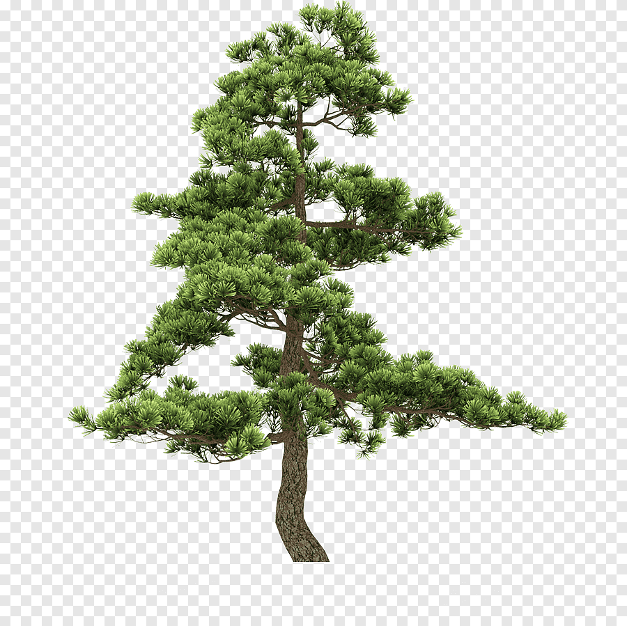

# **Lecture 6:** Hypothesis Components

Useful hypotheses:

- Rely on specifying
  - Ho is the hypothesis of “no effect”
    - two samples from population with same mean
    - sample is from population of mean = X
  - Ha (research or alternate hypothesis)
    - is the opposite of the Ho
    - or predicts that there is an effect of x on y
    - *but does NOT suggest a direction which is a prediction*

# **Lecture 6:** Hypothesis Examples

Together Ho and Ha encompass all possible outcomes:

- Ho: µ=0, Ha: µ ≠ 0
  - mean equals 0 or mean does not equal 0
- Ho: µ = 35, Ha: µ ≠ 35
  - mean equals 35 or mean does not equal 35
- Ho: µ1 = µ2, Ha: µ1 ≠ µ2
  - mean of population 1 equals mean of population 2 or it does not
- Ho: µ > 0, Ha: µ ≤ 0
  - can be directional mean is greater than 0 or mean is not equal or less than 0
  - this becomes a one sided test as it predicts only one direction

# **Lecture 6:** Statistical Testing Framework

Statistical tests assess likelihood of the null hypothesis being true

- If the Ho is likely false, then Ha assumed to be correct
- More precisely:
  - the long run probability of obtaining sample value (or more extreme one) if the null hypothesis is true
    - p(data|Ho) - the probability of observing the data given that the null hypothesis Ho is true

# **Lecture 6:** Understanding P-values

Hypothesis tests

- Expressed as p-value (0-never to 1-always )
- Interpret p-value as:
  - probability of obtaining sample value of statistic (or more extreme one) if Ho is true
- High p-value:
  - high probability of obtaining sample statistic under Ho
    - if the null hypothesis (Ho) were true, you would frequently observe data similar to your sample statistic
    - your observed results are quite compatible with what the null hypothesis predicts
- Low p-value: low probability of obtaining sample statistic under Ho
  - if the null hypothesis (Ho) were true, you would rarely observe data similar to or more extreme than your sample statistic
  - Your results are unusual under the null hypothesis, suggesting that either you’ve witnessed a rare event or the null hypothesis may be incorrect

# **Lecture 6:** P-value Interpretation

Statistical test results:

- p = 0.3 means that if I repeated the study 100 times, I would get this (or more extreme) result due to chance **30 times**
- p = 0.03 means that if I repeated the study 100 times, I would get this (or more extreme) result due to chance **3 times**

*Which p-value suggests Ho likely false?*

At what point reject Ho?

p < 0.05 conventional “significance threshold” (α = alpha or p value)

p < 0.05 means: if Ho is true and we repeated the study 100 times

- we would get this (or more extreme) result less than 5 times due to chance

# **Lecture 6:** Significance Levels and Interpretation

Statistical test results:

- **α is the rate at which we will reject a true null hypothesis (Type I error rate)**
- Lowering α will lower likelihood of incorrectly rejecting a true null hypothesis (e.g., 0.01, 0.001)
- *Both Hs and α are specified* *BEFORE collection of data and analysis*

Traditionally α=0.05 is used as a cut off for rejecting null hypothesis

There is nothing magical about 0.05 - actual p-values need to be reported - also need to decide prior to study

| p-value range | Interpretation |
| --- | --- |
| P > 0.10 | No evidence against Ho - data appear consistent with Ho |
| 0.05 < P < 0.10 | Weak evidence against the Ho in favor of Ha |
| 0.01 < P < 0.05 | Moderate evidence against Ho in favor of Ha |
| 0.001 < P < 0.01 | Strong evidence against Ho in favor of Ha |
| P < 0.001 | Very strong evidence against Ho in favor of Ha |

# **Lecture 6:** Understanding P-values Visually

A **p-value** is the probability of observing the sample result (or something more extreme) if the null hypothesis is true.

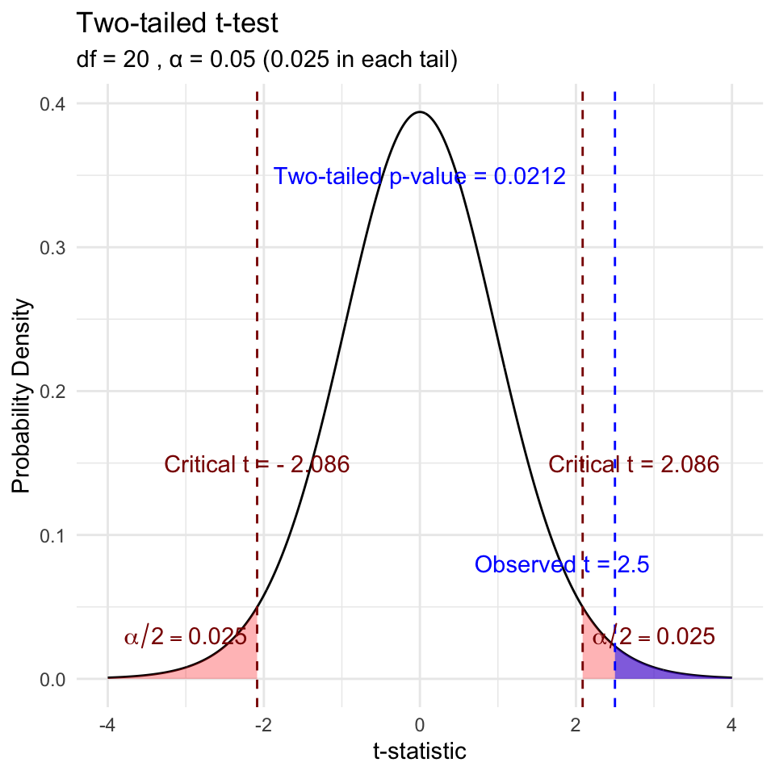

# **Lecture 6:** Historical Context

[figure not shown]

# **Lecture 6:** Fisher’s Perspective

Fisher:

p-value as informal measure of discrepancy between data and Ho

“If p is between 0.1 and 0.9 there is certainly no reason to suspect the hypothesis tested. If it is below 0.02 it is strongly indicated that the hypothesis fails to account for the whole of the facts. We shall not often be astray if we draw a conventional line at .05 …”

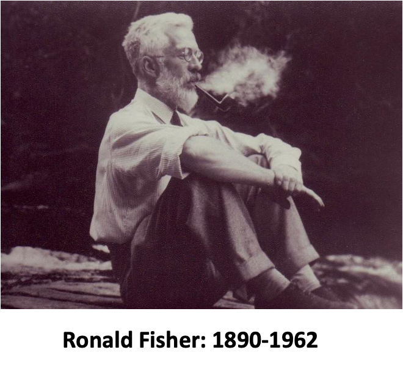

# **Decision errors**

- **Even good studies can reach incorrect conclusions**
- “Decision errors”
- Two types of decision errors
- Want to know probability of making these errors

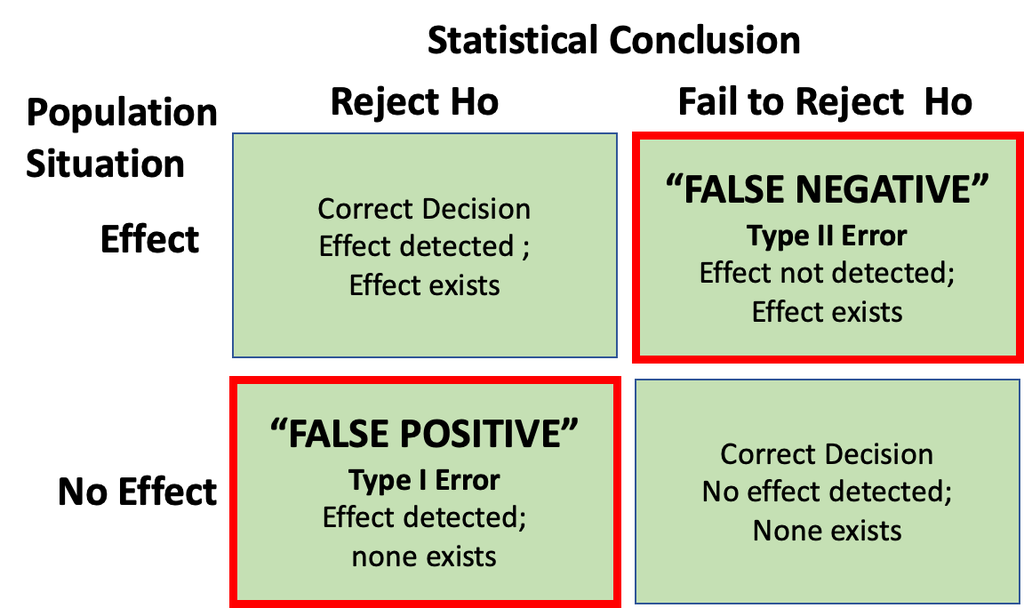

# **Type I and Type II Errors - Concept**

- **Type I error rate**
  - **α**: wrongly reject H₀ when it’s true
  - α = 0.05 means a type I error rate of 5%
- **Type II error rate, β**
  - wrongly fail to reject H₀ when it’s false
- **Power = 1-β**: **probability of correctly rejecting H₀ when H₁ is true**
- Inverse relationship between type I and type II error - but not straightforward
- Result of chance - sample not representative of population
- **Which type of error is more dangerous?**

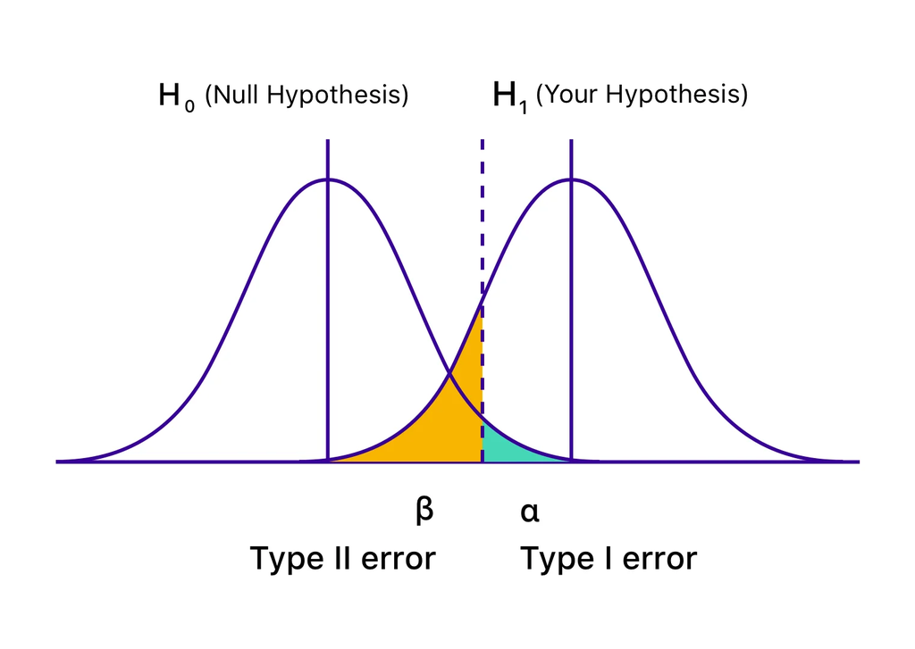

the dotted line is the alpha = 0.05

# **Lecture 6:** Type I and Type II Errors - Details

When making decisions based on hypothesis tests, two types of errors can occur:

**Type I Error (False Positive)**

- Rejecting H₀ when it’s actually true
- Probability = α (significance level)
- “Finding an effect that isn’t real”

**Type II Error (False Negative)**

- Failing to reject H₀ when it’s actually false
- Probability = β - “Missing an effect that is real”

**Statistical Power = 1 - β**

- Probability of correctly rejecting a false H₀
- Increases with:
  - Larger sample size
  - Larger effect size
  - Lower variability
  - Higher α level

The farther apart the means or lower variance the lower the beta error is ~ have higher power. - CLICK TO NEXT AS SAME TEXT

[figure not shown]

# **Lecture 6:** Type I and Type II Errors - Visualization

When making decisions based on hypothesis tests, two types of errors can occur:

**Type I Error (False Positive)**

- Rejecting H₀ when it’s actually true
- Probability = α (significance level)
- “Finding an effect that isn’t real”

**Type II Error (False Negative)**

- Failing to reject H₀ when it’s actually false
- Probability = β - “Missing an effect that is real”

**Statistical Power = 1 - β**

- Probability of correctly rejecting a false H₀
- Increases with:
  - Larger sample size
  - Larger effect size
  - Lower variability
  - Higher α level

The farther apart the means or lower variance the lower the beta error is ~ have higher power.

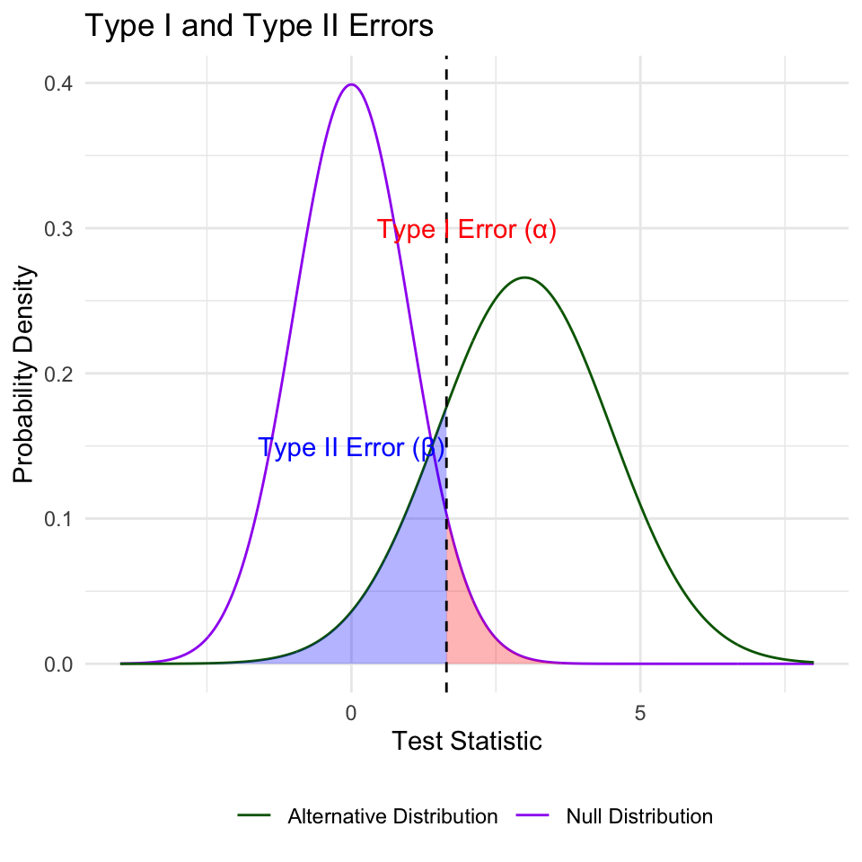

# Practice Exercise: Interpreting Errors and Power

**Practice Exercise 6: Interpreting P-values and Errors**

```r
library(car)
library(patchwork)
library(tidyverse)
library(readxl)

m_df <- read_csv("data/mice_weights.csv") %>%
  filter(!is.na(mass_g))


sidney_df <- m_df %>% filter(sampling_site=="Sidney Island")
vancouver_df <- m_df %>% filter(sampling_site=="Vancouver")
# Calculate power for detecting a 30 mm difference

n1 <- nrow(sidney_df)
n2 <- nrow(vancouver_df)
sd_pooled <- sqrt((var(sidney_df$mass_g) * (n1-1) +
                  var(vancouver_df$mass_g) * (n2-1)) /
                  (n1 + n2 - 2))

# Calculate power
effect_size <- 1 / sd_pooled  # Cohen's d
df <- n1 + n2 - 2
alpha <- 0.05
power <- power.t.test(n = min(n1, n2),
                     delta = effect_size,
                     sd = 1,  # Using standardized effect size
                     sig.level = alpha,
                     type = "two.sample",
                     alternative = "two.sided")

# Display results
power
```

```
     Two-sample t test power calculation

              n = 28
          delta = 0.4231154
             sd = 1
      sig.level = 0.05
          power = 0.3427604
    alternative = two.sided

NOTE: n is number in *each* group
```

# What if we calculated power for the pine needles you measured?

```r
pine_switch_df <- read_excel("data/class_pine needle length switched.xlsx")
ps_df <- pine_switch_df %>%
  group_by(group, tree_no, tree_char, side) %>%
  summarise(length_mm = mean(length_mm, na.rm=TRUE))

ps_shady_df <- ps_df %>%
  filter(side == "shady")

ps_sunny_df <- ps_df %>%
  filter(side == "sunny")

pine_alpha <- 0.05

# Calculate power for detecting a 30 mm difference

pine_n1 <- nrow(ps_shady_df)  # FIX: was using sidney_df instead of ps_shady_df
pine_n2 <- nrow(ps_sunny_df)  # FIX: was using vancouver_df instead of ps_sunny_df

pine_sd_pooled <- sqrt((var(ps_shady_df$length_mm) * (pine_n1-1) +
                       var(ps_sunny_df$length_mm) * (pine_n2-1)) /
                       (pine_n1 + pine_n2 - 2))  # FIX: was using n1, n2 instead of pine_n1, pine_n2

cat("Pooled SD:", round(pine_sd_pooled, 2), "mm\n\n")
```

```
Pooled SD: 2.58 mm
```

```r
# More realistic effect sizes to test:
observed_diff <- abs(mean(ps_shady_df$length_mm) - mean(ps_sunny_df$length_mm))
pine_effect_size_observed <- observed_diff / pine_sd_pooled
cat("Effect size for observed", round(observed_diff, 2), "mm difference: Cohen's d =", round(pine_effect_size_observed, 2), "\n")
```

```
Effect size for observed 1.45 mm difference: Cohen's d = 0.56
```

```r
# 2. Power for the observed difference
pine_power_observed <- power.t.test(n = min(pine_n1, pine_n2),
                                   delta = pine_effect_size_observed,
                                   sd = 1,
                                   sig.level = pine_alpha,
                                   type = "two.sample",
                                   alternative = "two.sided")

cat("Power for observed", round(observed_diff, 2), "mm difference:", round(pine_power_observed$power, 3), "\n")
```

```
Power for observed 1.45 mm difference: 0.182
```

# What is Power

A power analysis like this is typically done for one of these purposes:

1. Before data collection to determine required sample size
2. After a study to evaluate if the sample size was adequate
3. To determine the minimum detectable effect size with the given sample

# **Lecture 6:** Error Bars and Their Interpretation

Error bars are graphical representations of the variability of data that show:

- The **precision** of a measurement
- The **uncertainty** around an estimate
- A **confidence interval** for a parameter

Common types of error bars:

1. **Standard Error (SE)**: Shows precision of the mean
2. **Standard Deviation (SD)**: Shows variability in the data
3. **Confidence Interval (CI)**: Shows plausible range for parameter

When interpreting graphs:

- Always check what the error bars represent
- Non-overlapping 95% CI bars suggest statistically significant differences
- Error bars help assess both statistical and practical significance

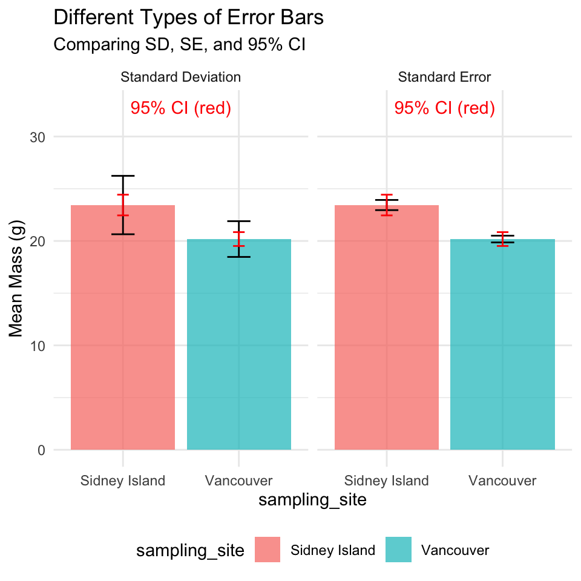

# **Lecture 6:** Sampling and Pseudoreplication

**Pseudoreplication** occurs when measurements that are not independent are analyzed as if they were independent.

- A critical consideration in experimental design
- Results in underestimated standard errors and confidence intervals
- Leads to inflated Type I error rates (false positives)

**Examples of pseudoreplication:**

- Measuring the same individual multiple times
- Treating multiple fish from the same tank as independent
- Using multiple data points from a single site

**How to avoid pseudoreplication:**

- Identify the true experimental unit
- Use appropriate statistical techniques (e.g., mixed models)
- Be clear about the level of replication

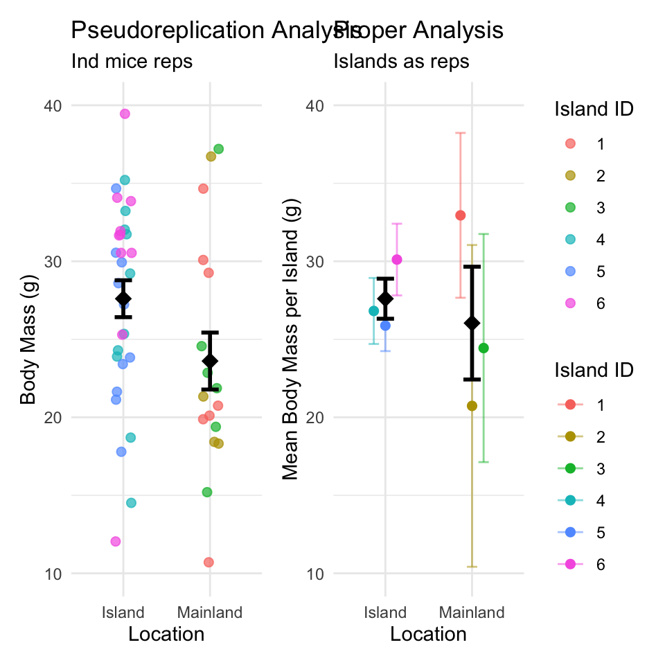

# **Lecture 6:** Summary and Key Takeaways

**Key concepts covered:**

1. **P-values** measure evidence against the null hypothesis
   - Not the probability that H₀ is true
   - Should be interpreted in context with effect size
2. **Hypothesis testing** provides a framework for making decisions
   - Null and alternative hypotheses must be specified beforehand
   - α level determines Type I error rate
3. **Type I and Type II errors** represent different kinds of mistakes
   - Type I (α): False positive - rejecting true H₀
   - Type II (β): False negative - failing to reject false H₀
   - Statistical power = 1 - β
4. **Error bars** communicate uncertainty in different ways
   - Always check what type of error bar is shown
   - CI bars help assess statistical significance
5. **Pseudoreplication** inflates significance
   - Identify true experimental units
   - Account for non-independence in analysis

Back to top